# Actividad01

Yangyang Li

21/2/2019

# 1 Statistical analysis and LR modelling

## 1.1 Cargar de datos

```r
data<-read.table(file="/Users/yangyangli/Downloads/datos_icb.txt",sep=" ", dec=".", header=TRUE)
head(data)
```

```
##   edad tam grado gang          feno quim horm recid
## 1   51 2.3    G1    0     Luminal A   No  Yes    NO
## 2   46 3.4    G3    4    Basal like  Yes   No    SI
## 3   49 2.1    G2    1 HER2 enriched  Yes  Yes    NO
## 4   31 1.7    G2    1    Basal like  Yes   No    NO
## 5   36 1.5    G3    0    Basal like  Yes   No    NO
## 6   59 3.8    G3    2     Luminal B  Yes  Yes    NO
```

```r
summary(data)
```

```
##       edad            tam         grado         gang
##  Min.   :25.00   Min.   : 0.200   G1: 76   Min.   : 0.000
##  1st Qu.:45.00   1st Qu.: 1.500   G2:279   1st Qu.: 0.000
##  Median :55.00   Median : 2.250   G3:145   Median : 1.000
##  Mean   :55.76   Mean   : 2.524            Mean   : 2.478
##  3rd Qu.:65.00   3rd Qu.: 3.000            3rd Qu.: 3.000
##  Max.   :88.00   Max.   :12.000            Max.   :34.000
##             feno      quim      horm     recid
##  Basal like   : 64   No :176   No :154   NO:424
##  HER2 enriched: 31   Yes:324   Yes:346   SI: 76
##  Luminal A    :240
##  Luminal B    :120
##  Luminal-HER2 : 21
##  TN no-basal  : 24
```

Hemos cuardado el conjunto de datos en la variable “data”, y utilizamos el comando **summary()** podemos obtener una vision global sobre los datos: tiene 8 variables y no tiene datos perdidos(“NA”). De los 8 variables, edad,tam(tumor size),gang(numero de ganglios) son variables numericas y restos son de tipo categoricas.

## 1.2 Analisis univariante

### 1.2.1 Variables numericas

#### 1.2.1.1 Edad

```r
summary(data$edad)
```

```
##    Min. 1st Qu.  Median    Mean 3rd Qu.    Max.
##   25.00   45.00   55.00   55.76   65.00   88.00
```

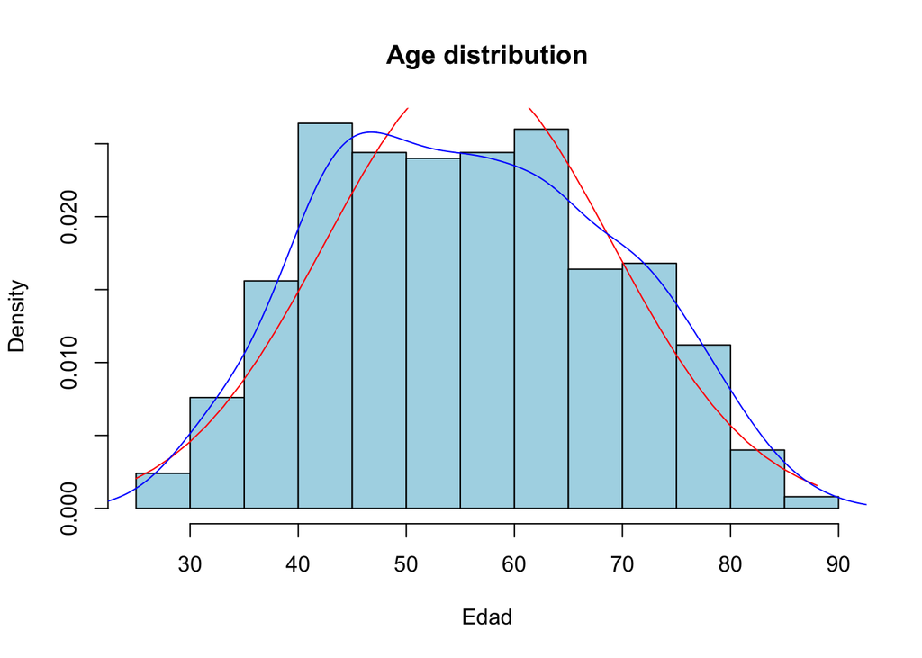

```r
hist(data$edad,freq = FALSE,col="light blue",main = "Age distribution",xlab = "Edad")
x<-seq(min(data$edad),max(data$edad),length=40)
y<-dnorm(x,mean(data$edad),sd(data$edad))
lines(x,y,col="red")
lines(density(data$edad),col="blue")
```

El summary() nos devuelve una descripcion basica sobre la “edad”, la media, mediana,minimo,maximo etc. La histograma nos da una sensacion de que la edad parece tiene una distribucion normal, para comprobar si es verdad, usamos: “Shapiro-Wilk normality test”

```r
#averiguar el hipostesis nulo
n <- rnorm(1000)
shapiro.test(n)
```

```
##
##  Shapiro-Wilk normality test
##
## data:  n
## W = 0.99888, p-value = 0.8076
```

```r
shapiro.test(data$edad)
```

```
##
##  Shapiro-Wilk normality test
##
## data:  data$edad
## W = 0.98554, p-value = 7.177e-05
```

El variable edad **no** tiene la distribucion normal ya que su p_valor es mucho menor que 0.05, rechaza el hipotesis nulo.

Tambien es interesante categorizar la edad porque no va haber mucha variacion entre casos con edades muy similares.

```r
data$edad_cat <- cut(data$edad,breaks=c(min(data$edad)-1,45,65,max(data$edad)))
table(data$edad_cat)
```

```
##
## (24,45] (45,65] (65,88]
##     130     247     123
```

#### 1.2.1.2 Numero de ganglios

```r
summary(data$gang)
```

```
##    Min. 1st Qu.  Median    Mean 3rd Qu.    Max.
##   0.000   0.000   1.000   2.478   3.000  34.000
```

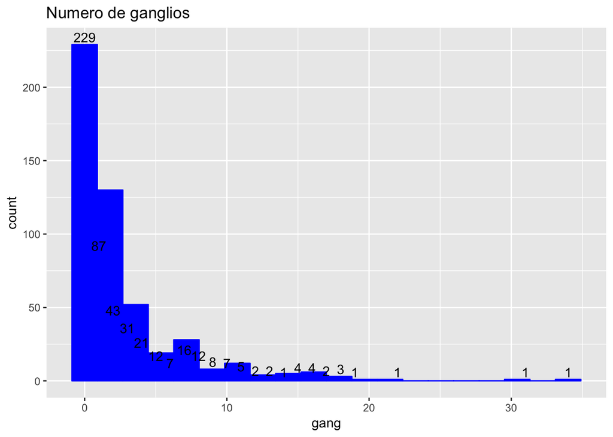

```r
ggplot(data = data, mapping = aes(x = gang)) +
  geom_histogram(color="blue", fill="blue", bins = 20)+labs(title = "Numero de ganglios")+geom_text( stat = "count",  aes(label = ..count..), vjust = -0.25)
```

Podemos obeservar mayor parte de los pacientes no tiene numero de ganglios elevado,entre 0-3.

#### 1.2.1.3 Tumor size

```r
summary(data$tam)
```

```
##    Min. 1st Qu.  Median    Mean 3rd Qu.    Max.
##   0.200   1.500   2.250   2.524   3.000  12.000
```

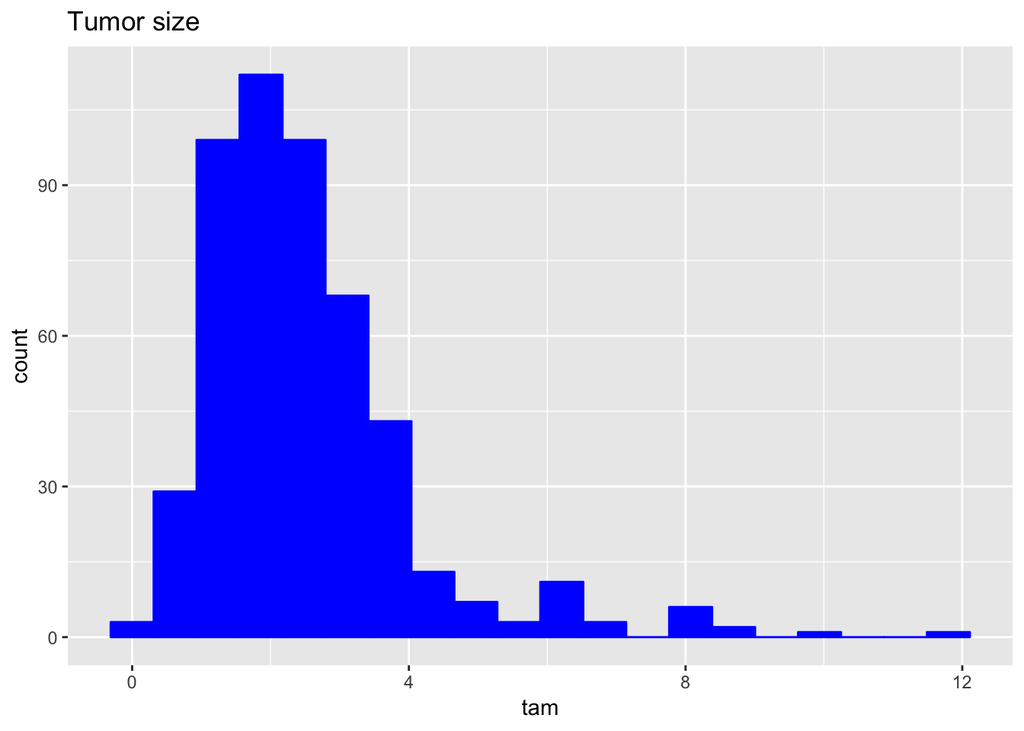

```r
ggplot(data = data, mapping = aes(x = tam)) +
  geom_histogram(color="blue", fill="blue", bins = 20)+labs(title = "Tumor size")
```

Mayor parte de los pacientes tiene su tumor size entre 0 a 3 $cm^3$.

### 1.2.2 Variables categoricas

#### 1.2.2.1 Fenotipo

Fenotipo tiene 6 niveles:

```r
levels(data$feno)
```

```
## [1] "Basal like"    "HER2 enriched" "Luminal A"     "Luminal B"
## [5] "Luminal-HER2"  "TN no-basal"
```

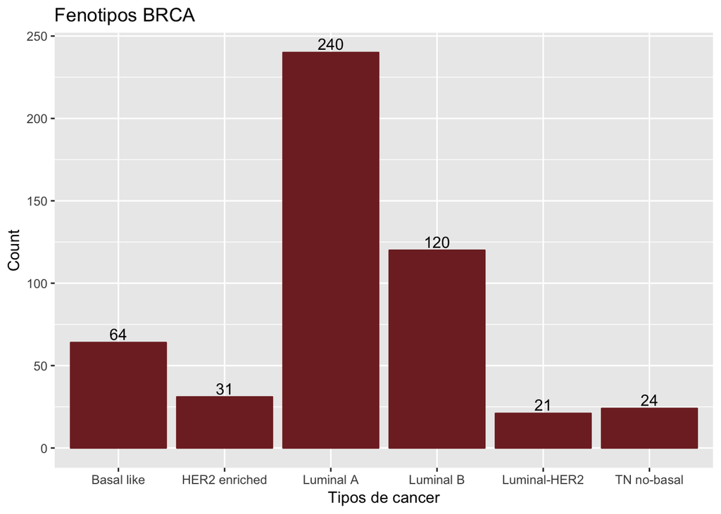

```r
p <- ggplot(data , mapping = aes(x = data$feno)) + geom_bar(col="#802A2A",fill="#802A2A")
p + labs(title = "Fenotipos BRCA",x = "Tipos de cancer",y = "Count"
)+geom_text( stat = "count", aes(label = ..count..),vjust = -0.25
)
```

Como demostrada de la grafica, la “luminalA” es un tipo mas comun en la muestra y “Luminal-HER2” , “TN no-basal” son tipos escasas.

#### 1.2.2.2 Grado

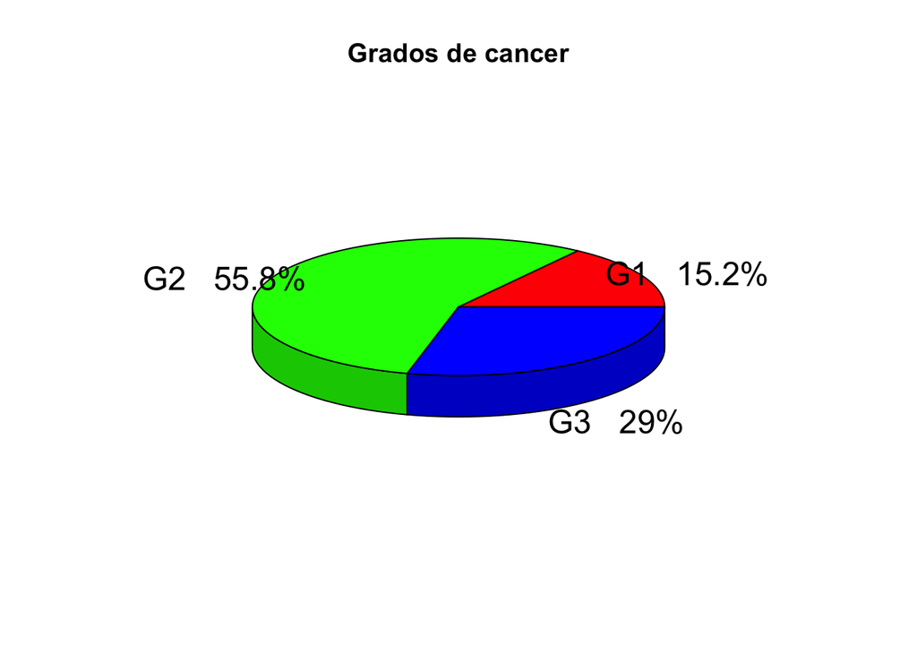

```r
grados <- table(data$grado)
label = c("G1","G2","G3")
piepercent<-round(100*grados/sum(grados), 1)
piepercent <-paste(piepercent, "%", sep = "")
pie3D(grados,labels=paste(label, piepercent,sep = "   "),explode=0,main="Grados de cancer")
```

Observamos hay 55.8% de los casos pertenecen al grado2.

#### 1.2.2.3 Quimioterapia y Hormonoterapia

Como son dos variables de tipo logical,y ambos son tratamientos, vamos a plot ambas en una grafica:

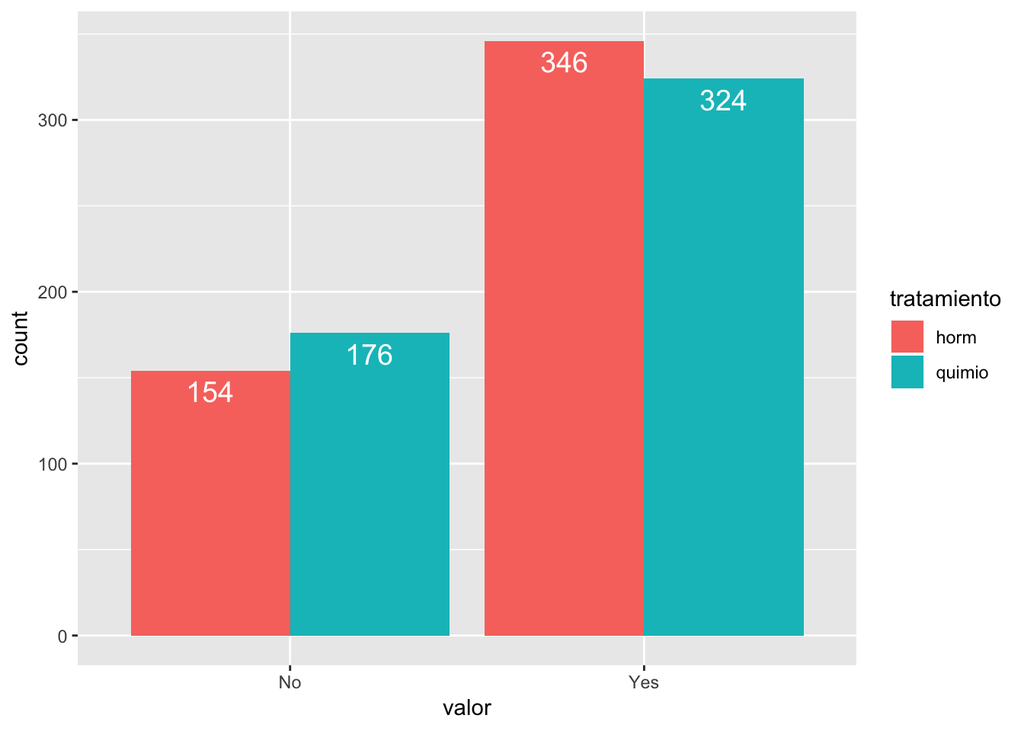

```r
t1 <- as.data.frame(table(data$quim))
t2 <- as.data.frame(table(data$horm))
t <- rbind(t1,t2)
colnames(t) <-c("valor","count")
t$tratamiento <- c("quimio","quimio","horm","horm")
ggplot(t, aes(x =valor, y = count, fill = tratamiento)) +
  geom_bar(position = "dodge", stat = "identity")+geom_text(aes(label = count), vjust = 1.5, colour = "white", position = position_dodge(.9), size = 5)
```

#### 1.2.2.4 Recid

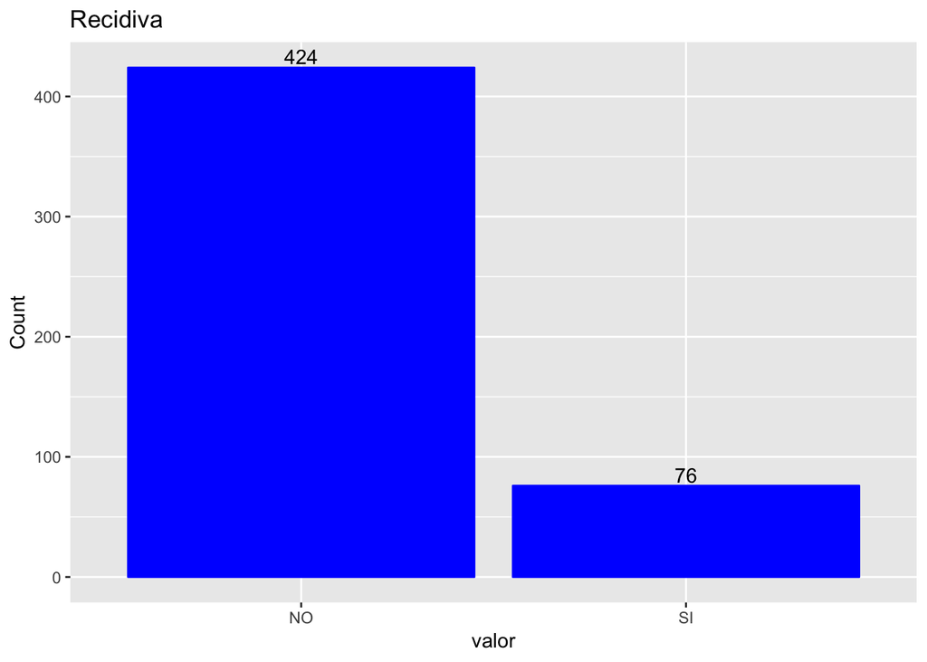

```r
p <- ggplot(data , mapping = aes(x = data$recid)) + geom_bar(col=" blue",fill="blue")
p + labs(title = "Recidiva",x = "valor",y = "Count"
)+geom_text( stat = "count", aes(label = ..count..),vjust = -0.25
)
```

## 1.3 Analisis bivariante

### 1.3.1 MatrixBivariantes

Construimos una matriz para ver si existe relacion entre las variables (p_valo<0.05):

```r
MatrixBivariantes <- function(x){
  table <- matrix(nrow=length(x),ncol=length(x))
  table<-as.data.frame(table)
  colnames(table)<-colnames(x)
  rownames(table)<-colnames(x)
  for (i in 1:length(x)) {
    for (j in 1:length(x)) {
      a <- colnames(table)[i]
      b <- colnames(table)[j]
      formula<-paste('~',a,'+',b)
      RegFormula <- paste(a,'~',b)
      RegFormula1 <- paste(b,'~',a)
      if(i==j){
        table[i,j]<-"X"
      }else
        if(is.factor(x[,i])&&is.factor(x[,j])){
        xtabs<-xtabs(formula,data=x)
        test <- chisq.test(xtabs)
        test <- as.list(test)
        table[i,j]<-round(as.numeric(test[3]),5)
        table[j,i]<-round(as.numeric(test[3]),5)
        }else
          if(is.numeric(x[,i])&&is.numeric(x[,j])){
                result <-as.list(summary(lm(RegFormula,data = x)))
                table[i,j] <- round(result$coefficients[2,4],5)
          }else
            if(is.factor(x[,i])&&is.numeric(x[,j])){
              result <-as.list(summary(glm(RegFormula,data =  x,family=binomial("logit"))))
              table[i,j] <- round(result$coefficients[2,4],5)
            }else
             if(is.numeric(x[,i])&&is.factor(x[,j])){
               result <-as.list(summary(glm(RegFormula1,data =  x,family=binomial("logit"))))
                # result <-summary(aov(RegFormula1,data =  x))[[1]]["Pr(>F)"][[1]][1]
               table[i,j] <- round(result$coefficients[2,4],5)
             }
      }}
      return(table)
}
dt <- MatrixBivariantes(data)
```

| variables | edad | tam | grado | gang | feno | quim | horm | recid | edad_cat |
| --- | --- | --- | --- | --- | --- | --- | --- | --- | --- |
| edad | X | 0.34756 | 0.17237 | 0.10767 | 0.00923 | 0 | 0 | 0.40621 | 0.9875 |
| tam | 0.34756 | X | 0.00028 | 0 | 0.06272 | 5e-05 | 0.53905 | 0 | 0.28062 |
| grado | 0.17237 | 0.00028 | X | 0.08227 | 0 | 0 | 0 | 0 | 0.0257 |
| gang | 0.10767 | 0 | 0.08227 | X | 0.76379 | 0 | 0.23822 | 0 | 0.38089 |
| feno | 0.00923 | 0.06272 | 0 | 0.76379 | X | 4e-05 | 0 | 0 | 0.43448 |
| quim | 0 | 5e-05 | 0 | 0 | 4e-05 | X | 1e-05 | 0.03138 | 0 |
| horm | 0 | 0.53905 | 0 | 0.23822 | 0 | 1e-05 | X | 0.00276 | 0 |
| recid | 0.40621 | 0 | 0 | 0 | 0 | 0.03138 | 0.00276 | X | 0.25249 |
| edad_cat | 0.9875 | 0.28062 | 0.0257 | 0.38089 | 0.43448 | 0 | 0 | 0.25249 | X |

### 1.3.2 Ejemplos con p_valor < 0.05:

-Grado & Fenotipo

```r
table(data$grado,data$feno)
```

```
##
##      Basal like HER2 enriched Luminal A Luminal B Luminal-HER2 TN no-basal
##   G1          0             1        60        14            0           1
##   G2         16            11       157        73           12          10
##   G3         48            19        23        33            9          13
```

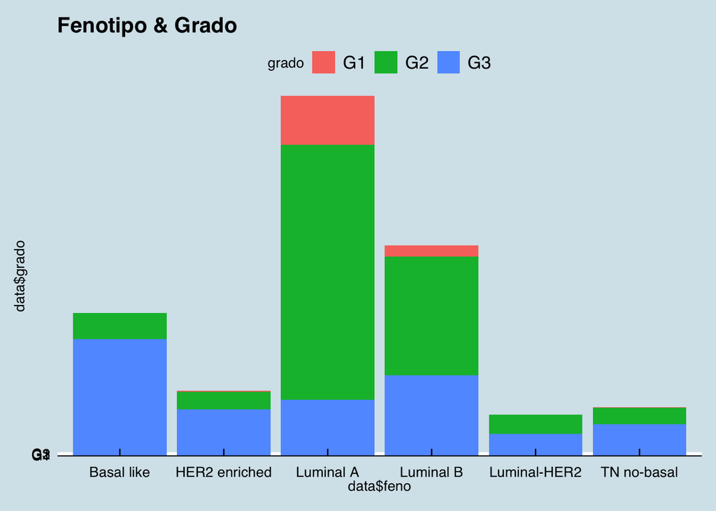

```r
ggplot(data,aes(data$feno,data$grado,fill=grado))+geom_bar(stat="identity",position="stack")+ggtitle("Fenotipo & Grado")+theme_economist(base_size=10)
```

-Numero de ganglios & Quimioterapia

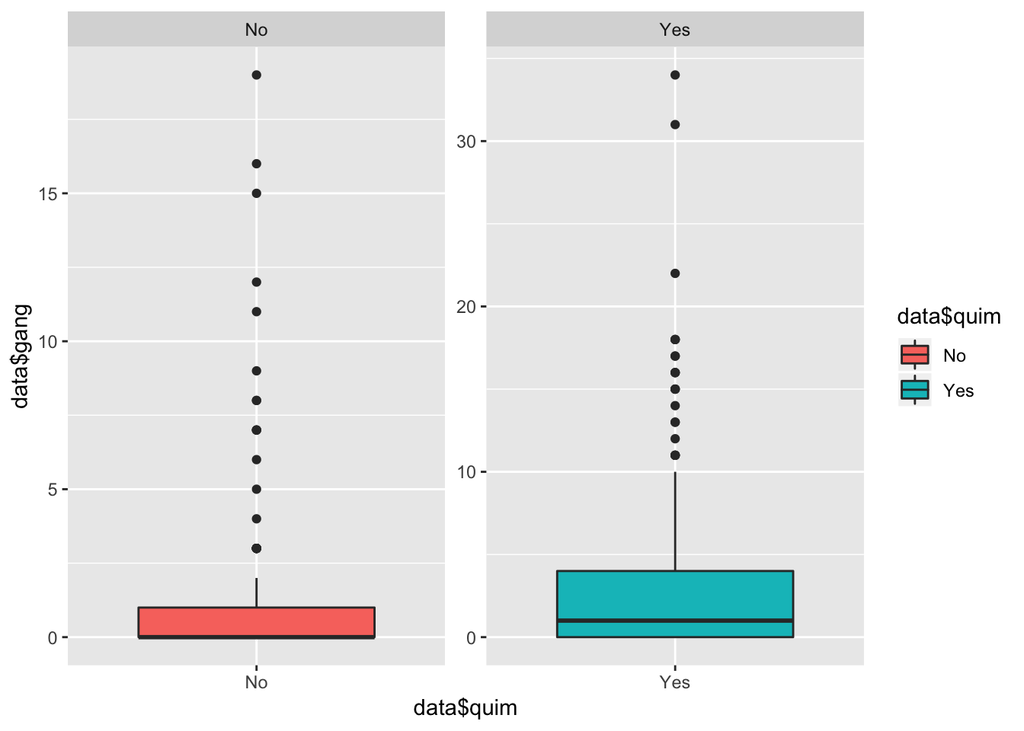

```r
p<-ggplot(data, aes(x=data$quim,y=data$gang))+geom_boxplot(aes(fill=data$quim))
p+ facet_wrap(~ data$quim, scales="free")
```

Vemos como anteriormente con el p_valor como a mayor numero de ganglios mayor probilidad de ser tratado con quimioterapia.

-Fenotipo & Hormonoterapia

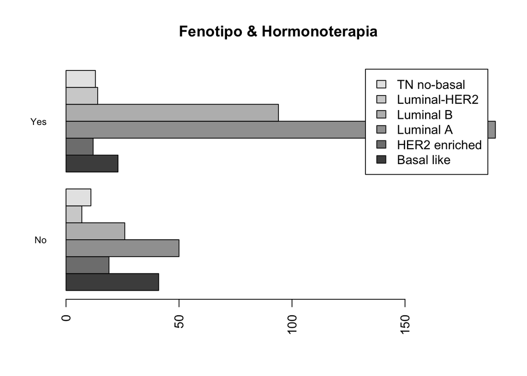

```r
barplot(table(data$feno,data$horm), beside= TRUE, legend.text = TRUE, horiz = T, cex.names = 0.75, las=2, main= "Fenotipo & Hormonoterapia")
```

Destacamos Luminal A el cual tiene altas probabilidades de sufrir terapia hormonal asi como Luminal B. Por otro lado HER2 enriched y Basal like presentan menos probabilidad de sufrir terapia hormonal.

## 1.4 Analisis multivariante

### 1.4.1 Funcion para calcular el “accuracy”

```r
ACC <- function(predict,patron){
  table <- matrix(ncol = 5,nrow = 1)
  colnames(table) <- c("TT","TF","FF","FT","ACC")
  conversion <- lapply(predict,calculo <- function(x){
                                   if(x>0.5){
                                      x="SI"
                                    }else
                                      x="NO" })
  conversion <- as.character( conversion)
  patron <- as.character(patron)
  TT<-0
  TF<-0
  FT<-0
  FF<-0
    for (i in 1:length(predict)) {
      if(conversion[i]==patron[i]&&patron[i]=="SI"){
        TT <- TT+1
      }else if(conversion[i]==patron[i]&&patron[i]=="NO"){
        TF<-TF+1
      }else if(conversion[i]=="SI"&&patron[i]=="NO"){
        FT<-FT+1
    }else FF<-FF+1
    }
  table[1,1] <- TT
  table[1,2] <- TF
  table[1,3] <- FF
  table[1,4] <- FT
  table[1,5] <-(TT+TF)/(TT+TF+FF+FT)
  table<-as.data.frame(table)
  return(table)
}
```

Una vez tengamos la funcion para calacular el “accuracy”, ya podemos comparar la calidad de las tres modelos obtenidos por diffrentes metodo: **stepAIC**,**Exhaustive search** y **stepACC**.

### 1.4.2 StepAIC

```r
mod.i<- glm((data$recid=="SI")*1.0~.,data,family=binomial("logit"))
mod.StepAIC<-stepAIC(mod.i,direction="back")
```

```
## Start:  AIC=374.23
## (data$recid == "SI") * 1 ~ edad + tam + grado + gang + feno +
##     quim + horm + edad_cat
##
##            Df Deviance    AIC
## - feno      5   351.31 371.31
## - quim      1   344.24 372.24
## - edad_cat  2   346.86 372.86
## - edad      1   344.87 372.87
## - horm      1   345.66 373.66
## <none>          344.23 374.23
## - grado     2   349.76 375.76
## - tam       1   353.30 381.30
## - gang      1   361.16 389.16
##
## Step:  AIC=371.31
## (data$recid == "SI") * 1 ~ edad + tam + grado + gang + quim +
##     horm + edad_cat
##
##            Df Deviance    AIC
## - quim      1   351.34 369.34
## - edad      1   351.78 369.78
## - edad_cat  2   353.83 369.83
## <none>          351.31 371.31
## - horm      1   353.85 371.85
## - tam       1   361.98 379.98
## - grado     2   364.90 380.90
## - gang      1   368.79 386.79
##
## Step:  AIC=369.34
## (data$recid == "SI") * 1 ~ edad + tam + grado + gang + horm +
##     edad_cat
##
##            Df Deviance    AIC
## - edad      1   351.89 367.89
## - edad_cat  2   353.90 367.90
## <none>          351.34 369.34
## - horm      1   353.88 369.88
## - tam       1   362.29 378.29
## - grado     2   365.49 379.49
## - gang      1   369.46 385.46
##
## Step:  AIC=367.89
## (data$recid == "SI") * 1 ~ tam + grado + gang + horm + edad_cat
##
##            Df Deviance    AIC
## - edad_cat  2   354.24 366.24
## <none>          351.89 367.89
## - horm      1   354.98 368.98
## - tam       1   362.34 376.34
## - grado     2   366.71 378.71
## - gang      1   370.60 384.60
##
## Step:  AIC=366.24
## (data$recid == "SI") * 1 ~ tam + grado + gang + horm
##
##         Df Deviance    AIC
## <none>       354.24 366.24
## - horm   1   356.63 366.63
## - tam    1   365.45 375.45
## - grado  2   368.87 376.87
## - gang   1   372.43 382.43
```

```r
mod.StepAIC$coefficients
```

```
## (Intercept)         tam     gradoG2     gradoG3        gang     hormYes
##  -3.7361340   0.2721118   0.8727834   1.7733067   0.1234141  -0.4505289
```

Obtenemos el modelo por metodo AIC “back”, las variables significativos para el recidiva son: tam,grado,numero de ganglios y hormonoterapia, con coeficientes como demuestra arriba, el intercept es beta0, donde corta el eje y, los demas numeros son coeficientes correspondientes a cada variable.

Ahora vamos a calcular la precision(accuracy) de este modelo:

```r
predictStepAIC <- predict(mod.StepAIC,data,type="response")
ACC(predictStepAIC,data$recid)
```

```
##   TT  TF FF FT  ACC
## 1 10 415 66  9 0.85
```

Nos da 85% de precision.

### 1.4.3 Exhaustive search

```r
ExhaustiveSearch <- function(data,name){
  n<-length(name)
  seleccion <- combos(n-1)
  seleccionMatrix<-seleccion$ragged
  acc <- 0
  resultado <-  name[seleccionMatrix[1,]]
  acc01 <- 0.5
  soluion <- list()
     for (i in 1:(2**(n-1)-1)) {
      variables <- name[seleccionMatrix[i,]]
      variablesF <-paste("(data$recid=='SI')*1.0",paste(variables,collapse = "+")
                                 ,sep = "~")
      formula <- as.formula(variablesF)
      modelo <- glm(formula,data,family=binomial("logit"))
      predict <- predict(modelo,data,type="response")
      acc <- ACC(predict,data$recid)
      coefficientes <- modelo$coefficients
      if(acc$ACC>acc01){
        resultado <- formula
        acc01 <- acc$ACC
        soluion <- append(resultado,acc01)
      }
     }
   return(soluion)
}
# quitamos las variables edad y recid porque edad no nos interesa, y recid es el variable dependiente.
ExhaustiveSearch(data,colnames(data[-c(1,8)]))
```

```
## [[1]]
## (data$recid == "SI") * 1 ~ tam + grado + quim
## <environment: 0x7f96896fe3b0>
##
## [[2]]
## [1] 0.862
```

Con el modelo obtenido por “Exhaustive search”, “accuray”=86%, las vairables significativas son como demostrado arriba: tam,grado,quim.

### 1.4.4 stepACC

```r
stepACC_forward <- function(data,variables){
    tablaResultado <- list()
    acc0 <- 0.5
    result <- "tam"
  for (i in 1:(length(variables)-1)) {
      v <- variables[i]
  for (j in (i+1):(length(variables)-1)) {
      v <- c(v,variables[j])

      formula0 <-paste("(data$recid=='SI')*1.0",paste(v,collapse = "+")
                                 ,sep = "~")
      formula1 <- as.formula(formula0)
      mod <- glm(formula1,data,family=binomial("logit"))
      predict <- predict(mod,data,type="response")
      acc <- (ACC(predict,data$recid))$ACC
      if(acc>acc0){
        acc0 <- acc
        result <- v
        tablaResultado <- acc
        tablaResultado <- append(tablaResultado,result)
      }else
        v <- result
    }
  }
return(tablaResultado)
}
stepACC_forward(data,colnames(data)[-c(1,8)])
```

```
## [1] "0.862" "tam"   "grado" "quim"
```

Con el metodo de stepACC obtenemos un modelo que tiene la accuracy= 86.2% , es igual que el resltado obtenido por el metodo Exhaustive search, son igual de buena de calidad.

### 1.4.5 Conclusion

[output not shown]

El “ExhaustiveSearch” y “stepACC” nos proponen mejor modelos ya que ExhaustiveSearch compara todas las posibles combinaciones de variables y stepACC tambien prueba todas las combinaciones en manera “step forward”, ambas metodos cuardan la mejor opcion (la que da mayor accuracy).